# Análisis de varianza

MSc. Darío Alvarado

[figure not shown]

Un análisis de varianza es una fórmula estadística que compara las varianzas entre las medias (promedio) de diferentes grupos para comprobar si hay diferencias entre ellas.

#### Paquetes

```r
library(car)
library(tidyverse)
library(agricolae)
library(palmerpenguins)
library(FSA)
library(ggeffects)
library(ggsignif)
```

### Contenido

#### Datos

```r
data("penguins")
penguins <- drop_na(penguins, flipper_length_mm)
head(penguins)
```

```
## # A tibble: 6 × 8
##   species island    bill_length_mm bill_depth_mm flipper_length_mm body_mass_g
##   <fct>   <fct>              <dbl>         <dbl>             <int>       <int>
## 1 Adelie  Torgersen           39.1          18.7               181        3750
## 2 Adelie  Torgersen           39.5          17.4               186        3800
## 3 Adelie  Torgersen           40.3          18                 195        3250
## 4 Adelie  Torgersen           36.7          19.3               193        3450
## 5 Adelie  Torgersen           39.3          20.6               190        3650
## 6 Adelie  Torgersen           38.9          17.8               181        3625
## # ℹ 2 more variables: sex <fct>, year <int>
```

Volver arriba

Inicio

#### ANOVA

**ANOVA** (Analysis of variance) = **ANDEVA** (Análisis de varianza)

A diferencia de la prueba de T-Student, un ANOVA puede comparar las varianzas entre tres o más grupos.

Para realizar un ANOVA nuestros datos deben cumplir los **supuestos de normalidad** y **homogeneidad de varianza** ya que esta es una **prueba paramétrica**.

```r
# separamos por grupos de interés para evaluar la normalidad
sa <- subset(penguins, species == "Adelie")
sc <- subset(penguins, species == "Chinstrap")
sg <- subset(penguins, species == "Gentoo")
```

```r
# evaluamos la normalidad de los datos
shapiro.test(sa$flipper_length_mm)
```

```
##
##  Shapiro-Wilk normality test
##
## data:  sa$flipper_length_mm
## W = 0.99339, p-value = 0.72
```

```r
shapiro.test(sc$flipper_length_mm)
```

```
##
##  Shapiro-Wilk normality test
##
## data:  sc$flipper_length_mm
## W = 0.98891, p-value = 0.8106
```

```r
shapiro.test(sg$flipper_length_mm)
```

```
##
##  Shapiro-Wilk normality test
##
## data:  sg$flipper_length_mm
## W = 0.96219, p-value = 0.00162
```

```r
# evaluamos la homogeneidad de la varianza
leveneTest(flipper_length_mm ~ species, data = penguins)
```

```
## Levene's Test for Homogeneity of Variance (center = median)
##        Df F value Pr(>F)
## group   2  0.3306 0.7188
##       339
```

##### ANOVA de una vía

También conocido como ANOVA de un factor o unidireccional, sirve para estudiar la relación entre una variable respuesta (dependiente) cuantitativa y una variable predictora (independiente) categórica (cualitativa) con varios niveles (grupos).

Podemos realizar el ANOVA con la función `aov()` del paquete base de R:

```r
anova <- aov(flipper_length_mm ~ species, data = penguins) # Aquí el orden de las variables si importa, colocamos primero nuestra variable respuesta y después nuestra variable predictora.
```

*Nota: El ANOVA solo permite variables predictoras categóricas.*

Para ver el resultado del ANOVA realizamos un `summary()`:

```r
summary(anova)
```

```
##              Df Sum Sq Mean Sq F value Pr(>F)
## species       2  52473   26237   594.8 <2e-16 ***
## Residuals   339  14953      44
## ---
## Signif. codes:  0 '***' 0.001 '**' 0.01 '*' 0.05 '.' 0.1 ' ' 1
```

En la primera columna del output encontramos las fuentes de variación: el **factor** (tratamiento o variable explicativa) y los **Residuals** que es la variación no explicada (error).

La columna **Df** (degrees of freedom) indica los grados de libertad de cada fuente de variación (n-1).

La Suma de Cuadrados (**Sum Sq**) cuantifica la variabilidad total asociada a cada fuente.

El Cuadrado Medio (**Mean Sq**) es la suma de cuadrados dividida entre los grados de libertad

El Estadístico F (**F value**) es la razón entre el Mean Sq del factor y el Mean Sq del error.

Un valor F alto indica que la variación entre grupos es mucho mayor que la variación dentro de los grupos.

El valor de p (Pr(>F)) indica la probabilidad de observar un valor F igual o mayor al obtenido si la hipótesis nula fuera cierta.

- Si el valor de **p < 0.05**, la diferencia entre la varianza de las medias entre al menos dos grupos es estadísticamente significativa.
- Si el valor de **p ≥ 0.05**, no hay diferencias estadísticamente significativas entre los grupos.

##### ANOVA de dos vías

El ANOVA de dos vías, también conocido como plan factorial con dos factores, sirve para estudiar la relación entre una variable respuesta cuantitativa y dos variables predictoras categóricas, cada una con varios niveles.

```r
anova2vias <- aov(flipper_length_mm ~ species + island, data = penguins) # para la segunda variable predictora colocamos un `+`.

summary(anova2vias)
```

```
##              Df Sum Sq Mean Sq F value Pr(>F)
## species       2  52473   26237 596.901 <2e-16 ***
## island        2    140      70   1.598  0.204
## Residuals   337  14813      44
## ---
## Signif. codes:  0 '***' 0.001 '**' 0.01 '*' 0.05 '.' 0.1 ' ' 1
```

Volver arriba

Inicio

#### Pruebas de contraste

El ANOVA solo nos brinda la significancia estadística de la comparación entre los grupos, por lo que se debe realizar una **prueba de contraste** entre las medias de los diferentes grupos. Estas pruebas también se conocen como pruebas **post hoc**.

##### Prueba post hoc de Tukey

Podemos realizar la **prueba de Tukey** con la función `TukeyHSD()` del paquete base de R, especificando la variable que contiene los diferentes grupos. Esta prueba utiliza el criterio de diferencia honestamente significativa o “honestly significant difference” (HSD).

```r
contraste <- TukeyHSD(anova, "species")
contraste
```

```
##   Tukey multiple comparisons of means
##     95% family-wise confidence level
##
## Fit: aov(formula = flipper_length_mm ~ species, data = penguins)
##
## $species
##                       diff       lwr       upr p adj
## Chinstrap-Adelie  5.869887  3.586583  8.153191     0
## Gentoo-Adelie    27.233349 25.334376 29.132323     0
## Gentoo-Chinstrap 21.363462 19.000841 23.726084     0
```

El resultado nos muestra los diferentes niveles de la variable predictora, en este caso las especies, contrastando los diferentes niveles. Se muestra la diferencia de la variable respuesta entre las medias de cada nivel de la variable predictora, los intérvalos de confianza al 95% y el valor de p para la significancia estadística de las diferencias.

También se puede realizar este contraste con la función `HSD.test()` del paquete `agricolae`:

```r
contraste2 <- HSD.test(anova, "species")
contraste2
```

```
## $statistics
##   MSerror  Df     Mean       CV
##   44.1099 339 200.9152 3.305638
##
## $parameters
##    test  name.t ntr StudentizedRange alpha
##   Tukey species   3         3.329136  0.05
##
## $means
##           flipper_length_mm      std   r        se Min Max Q25 Q50 Q75
## Adelie             189.9536 6.539457 151 0.5404799 172 210 186 190 195
## Chinstrap          195.8235 7.131894  68 0.8054037 178 212 191 196 201
## Gentoo             217.1870 6.484976 123 0.5988465 203 231 212 216 221
##
## $comparison
## NULL
##
## $groups
##           flipper_length_mm groups
## Gentoo             217.1870      a
## Chinstrap          195.8235      b
## Adelie             189.9536      c
##
## attr(,"class")
## [1] "group"
```

Con esta función el resultado nos muestra los **grupos de significancia estadística** de acuerdo a las diferencias que hay entre los niveles de la variable predictora.

Si dos niveles tienen letras iguales, la diferencia de la variable respuesta entre esos dos niveles no es estadísticamente significativa, pero si tienen letras diferentes la diferencia si es estadísticamente significativa.

##### Prueba LSD de Fisher

Esta prueba utiliza el criterio de diferencia mínima significativa o “least significant difference” (LSD) de Fisher para realizar el contraste entre las medias. Podemos realizarla con la función `LSD.test()` del paquete `agricolae`:

```r
contraste3 <- LSD.test(anova, "species")
contraste3
```

```
## $statistics
##   MSerror  Df     Mean       CV
##   44.1099 339 200.9152 3.305638
##
## $parameters
##         test p.ajusted  name.t ntr alpha
##   Fisher-LSD      none species   3  0.05
##
## $means
##           flipper_length_mm      std   r        se      LCL      UCL Min Max
## Adelie             189.9536 6.539457 151 0.5404799 188.8905 191.0168 172 210
## Chinstrap          195.8235 7.131894  68 0.8054037 194.2393 197.4077 178 212
## Gentoo             217.1870 6.484976 123 0.5988465 216.0091 218.3649 203 231
##           Q25 Q50 Q75
## Adelie    186 190 195
## Chinstrap 191 196 201
## Gentoo    212 216 221
##
## $comparison
## NULL
##
## $groups
##           flipper_length_mm groups
## Gentoo             217.1870      a
## Chinstrap          195.8235      b
## Adelie             189.9536      c
##
## attr(,"class")
## [1] "group"
```

##### Prueba post hoc de Duncan

Otra alternativa es la **prueba de Duncan**. Podemos ejecutarla con la función `duncan.test()` del paquete `agricolae`:

```r
contraste4 <- duncan.test(anova, "species")
contraste4
```

```
## $statistics
##   MSerror  Df     Mean       CV
##   44.1099 339 200.9152 3.305638
##
## $parameters
##     test  name.t ntr alpha
##   Duncan species   3  0.05
##
## $duncan
## NULL
##
## $means
##           flipper_length_mm      std   r        se Min Max Q25 Q50 Q75
## Adelie             189.9536 6.539457 151 0.5404799 172 210 186 190 195
## Chinstrap          195.8235 7.131894  68 0.8054037 178 212 191 196 201
## Gentoo             217.1870 6.484976 123 0.5988465 203 231 212 216 221
##
## $comparison
## NULL
##
## $groups
##           flipper_length_mm groups
## Gentoo             217.1870      a
## Chinstrap          195.8235      b
## Adelie             189.9536      c
##
## attr(,"class")
## [1] "group"
```

Para el contraste del ANOVA de dos vías podemos utilizar cualquier opción de las anteriores, pero debemos especificar las dos variables predictoras.

```r
contraste2vias <- HSD.test(anova2vias, c("species", "island")) # colocamos las dos variables predictoras concatenadas con `c()`.

contraste2vias
```

```
## $statistics
##    MSerror  Df     Mean      CV
##   43.95478 337 200.9152 3.29982
##
## $parameters
##    test         name.t ntr StudentizedRange alpha
##   Tukey species:island   5         3.878629  0.05
##
## $means
##                  flipper_length_mm      std   r        se Min Max    Q25   Q50
## Adelie:Biscoe             188.7955 6.729247  44 0.9994860 172 203 184.75 189.5
## Adelie:Dream              189.7321 6.585083  56 0.8859497 178 208 185.00 190.0
## Adelie:Torgersen          191.1961 6.232238  51 0.9283633 176 210 187.00 191.0
## Chinstrap:Dream           195.8235 7.131894  68 0.8039862 178 212 191.00 196.0
## Gentoo:Biscoe             217.1870 6.484976 123 0.5977926 203 231 212.00 216.0
##                  Q75
## Adelie:Biscoe    193
## Adelie:Dream     193
## Adelie:Torgersen 195
## Chinstrap:Dream  201
## Gentoo:Biscoe    221
##
## $comparison
## NULL
##
## $groups
##                  flipper_length_mm groups
## Gentoo:Biscoe             217.1870      a
## Chinstrap:Dream           195.8235      b
## Adelie:Torgersen          191.1961      c
## Adelie:Dream              189.7321      c
## Adelie:Biscoe             188.7955      c
##
## attr(,"class")
## [1] "group"
```

Volver arriba

Inicio

#### Gráficos

Podemos representar gráficamente las pruebas de contraste con la función `plot()`.

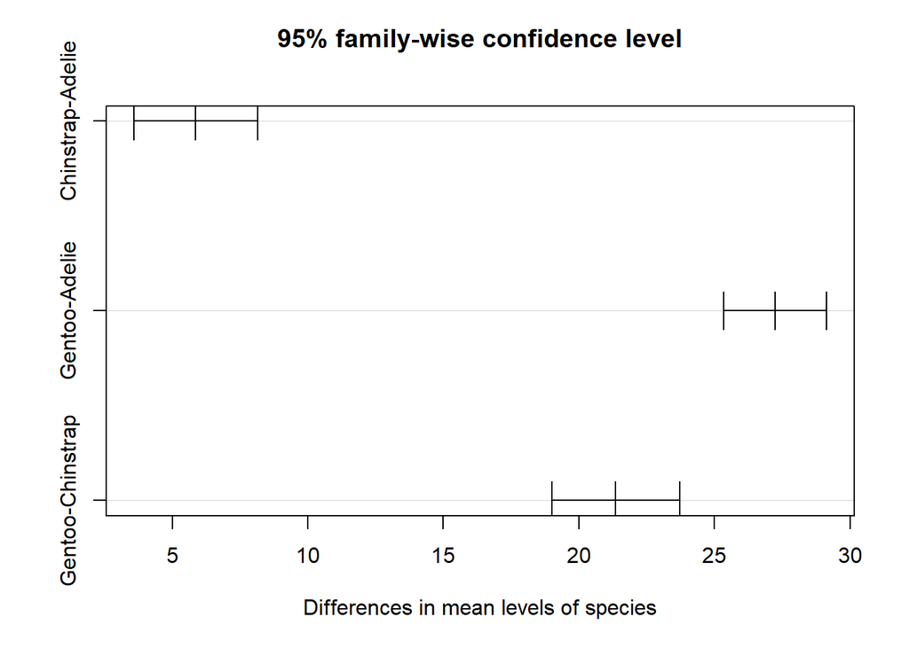

```r
# Gráfico de la función `TukeyHSD()`
plot(contraste)
```

```r
# Gráfico de la función `HSD.test()`.
plot(contraste2)
```

[output not shown]

```r
# Gráfico de la función `LSD.test()`.
plot(contraste3)
```

[output not shown]

```r
# Gráfico de la función `duncan.test()`
plot(contraste4)
```

[output not shown]

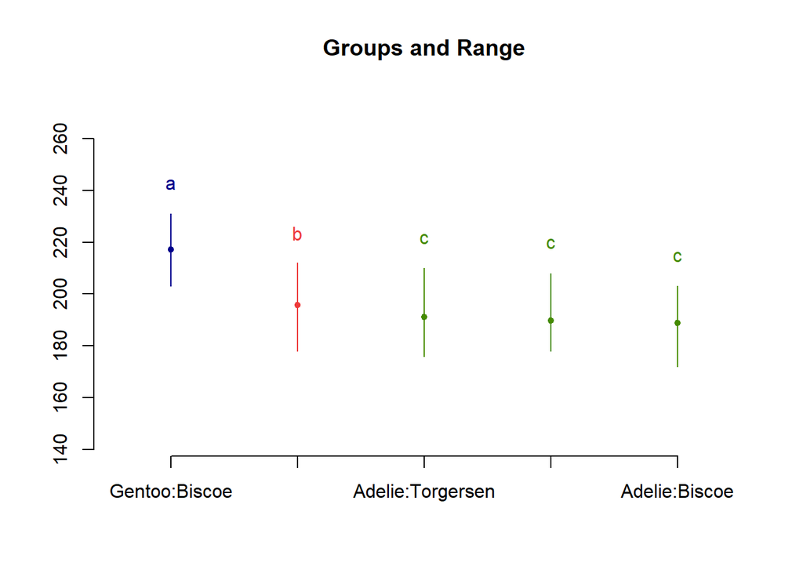

```r
# Gráfico para el contraste de 2 vías`
plot(contraste2vias)
```

Para realizar gráficos más elaborados utilizamos el paquete `ggplot2`.

Podemos hacerlo de varias formas:

Extraemos las medias de la salida de la prueba de contraste de la función `HSD.test` y lo convertimos en un dataframe:

```r
medias <- data.frame(contraste2$means)
medias
```

```
##           flipper_length_mm      std   r        se Min Max Q25 Q50 Q75
## Adelie             189.9536 6.539457 151 0.5404799 172 210 186 190 195
## Chinstrap          195.8235 7.131894  68 0.8054037 178 212 191 196 201
## Gentoo             217.1870 6.484976 123 0.5988465 203 231 212 216 221
```

```r
# El error estándar (se) es el error que calcula la prueba para cada grupo e indica la precisión de la estimación (estadística inferencial)
```

Con el error estándar podemos calcular el intervalo de confianza al 95%.

El IC95% se calcula multiplicando el error estándar por el *valor Z* para ese nivel de confianza.

- Z = 1.96, para IC95%
- Z = 1.645 para IC90%
- Z = 2.33 para IC98%
- Z = 2.757 para IC99%

```r
medias$IC95 <- medias$se * 1.96
medias$liIC95 <- medias$flipper_length_mm - medias$ IC95 # límite inferior del IC95%
medias$lsIC95 <- medias$flipper_length_mm + medias$IC95 # límite superior del IC95%
```

```r
medias
```

```
##           flipper_length_mm      std   r        se Min Max Q25 Q50 Q75     IC95
## Adelie             189.9536 6.539457 151 0.5404799 172 210 186 190 195 1.059341
## Chinstrap          195.8235 7.131894  68 0.8054037 178 212 191 196 201 1.578591
## Gentoo             217.1870 6.484976 123 0.5988465 203 231 212 216 221 1.173739
##             liIC95   lsIC95
## Adelie    188.8943 191.0130
## Chinstrap 194.2449 197.4021
## Gentoo    216.0133 218.3607
```

Con estos datos procedemos a graficar:

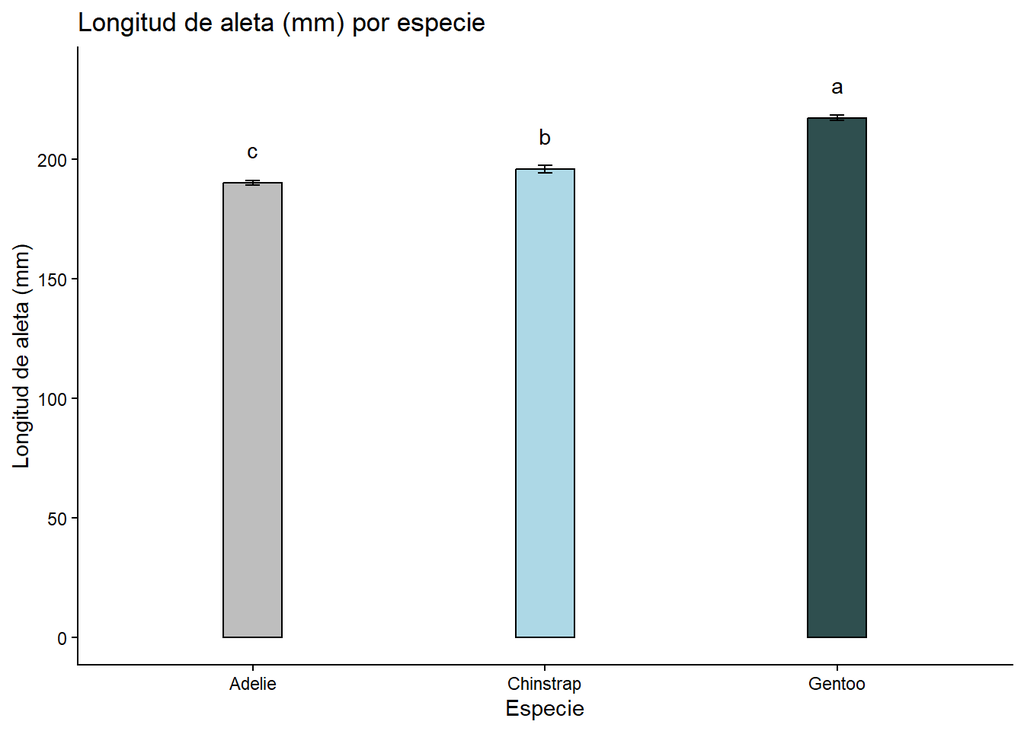

```r
# Gráfico de columnas con barras de error (con el IC95%)
ggplot(medias, aes(row.names(medias), flipper_length_mm)) +
  geom_col(width = 0.2,
           color = "black",
           fill = c("gray", "lightblue", "darkslategray")) +
  geom_errorbar(aes(ymin = liIC95, ymax = lsIC95), # indicamos el límite inferior y superior que tendran nuestras barras de error
                width = 0.05,
                ) +
  labs(title = "Longitud de aleta (mm) por especie",
       y = "Longitud de aleta (mm)",
       x = "Especie") +
  geom_text(aes(label = c("c", "b", "a")), # agregamos los grupos de nuestro resultado de la prueba de contraste
            vjust = -1.5) + # modificamos la posición de las etiquetas verticalmente
  ylim(c(0,235)) +
  theme(plot.title = element_text(hjust = 0.5)) + # centramos nuestro título del gráfico
  theme_classic()
```

Una mejor manera de graficar este tipo de resultados es mediante gráficos de punto con barras de error:

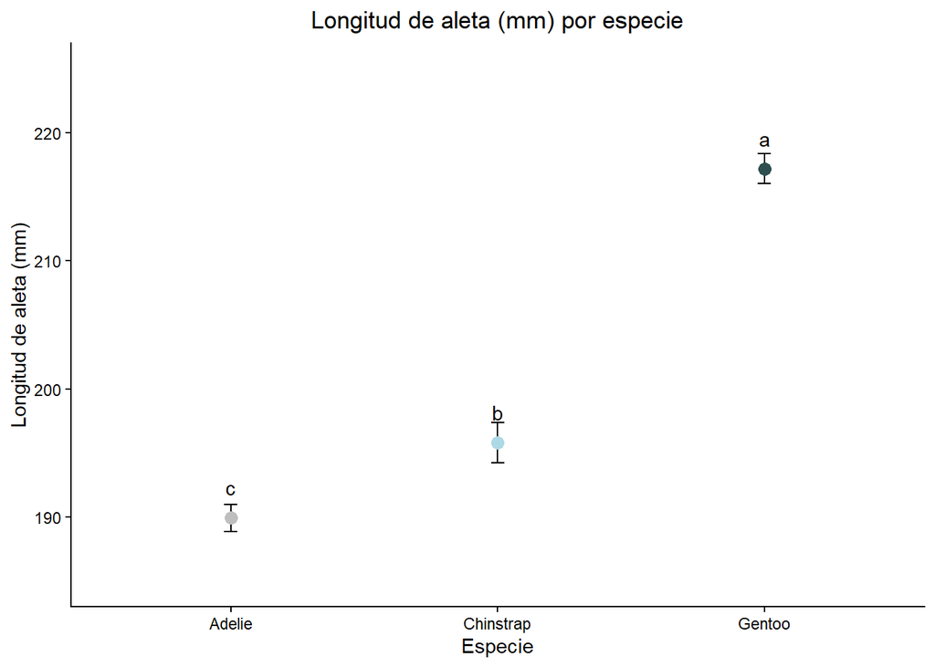

```r
# Gráfico de punto con barras de error
ggplot(medias, aes(row.names(medias), flipper_length_mm)) +
  geom_errorbar(width = 0.05,
                aes(ymin = liIC95,
                    ymax = lsIC95)) +
  geom_point(shape = 19,
             size = 3,
             color = c("gray", "lightblue", "darkslategray")) +
labs(title = "Longitud de aleta (mm) por especie",
     y = "Longitud de aleta (mm)",
     x = "Especie") +
  geom_text(aes(label = c("c", "b", "a")),
            vjust = -1.5) +
  ylim(c(185,225)) +
  theme_classic() +
  theme(plot.title = element_text(hjust = 0.5))
```

```r
ggsave("Imagenes/anova.jpg")
```

También podemos calcular las medias y los intervalos de confianza con la función `ggpredict()` del paquete `ggeffects`:

[figure not shown]

```r
pred <- ggpredict(anova, terms = "species")
ggplot(pred, aes(x, predicted)) +
  geom_point(size = 2) +
  geom_errorbar(aes(ymin = conf.low, ymax = conf.high),
                width = 0.05) +
  labs(y = "Longitud de aleta (mm)",
       x = "Especie") +
  geom_signif(data = penguins, aes(species, flipper_length_mm),
              comparisons = list(c("Adelie", "Chinstrap"),
                                 c("Adelie", "Gentoo"),
                                 c("Chinstrap", "Gentoo")),
              size = 0.5,
              map_signif_level = TRUE,
              y_position = c(196,217,220),
              tip_length = 0.01) +
  theme_classic()
```

Para el contraste del ANOVA de dos vías hacemos lo mismo:

```r
medias2vias <- data.frame(contraste2vias$means)
medias2vias
```

```
##                  flipper_length_mm      std   r        se Min Max    Q25   Q50
## Adelie:Biscoe             188.7955 6.729247  44 0.9994860 172 203 184.75 189.5
## Adelie:Dream              189.7321 6.585083  56 0.8859497 178 208 185.00 190.0
## Adelie:Torgersen          191.1961 6.232238  51 0.9283633 176 210 187.00 191.0
## Chinstrap:Dream           195.8235 7.131894  68 0.8039862 178 212 191.00 196.0
## Gentoo:Biscoe             217.1870 6.484976 123 0.5977926 203 231 212.00 216.0
##                  Q75
## Adelie:Biscoe    193
## Adelie:Dream     193
## Adelie:Torgersen 195
## Chinstrap:Dream  201
## Gentoo:Biscoe    221
```

```r
medias2vias$IC95 <- medias2vias$se * 1.96
medias2vias$liIC95 <- medias2vias$flipper_length_mm - medias2vias$ IC95# límite inferior del IC95%
medias2vias$lsIC95 <- medias2vias$flipper_length_mm + medias2vias$IC95 # límite superior del IC95%
```

```r
medias2vias
```

```
##                  flipper_length_mm      std   r        se Min Max    Q25   Q50
## Adelie:Biscoe             188.7955 6.729247  44 0.9994860 172 203 184.75 189.5
## Adelie:Dream              189.7321 6.585083  56 0.8859497 178 208 185.00 190.0
## Adelie:Torgersen          191.1961 6.232238  51 0.9283633 176 210 187.00 191.0
## Chinstrap:Dream           195.8235 7.131894  68 0.8039862 178 212 191.00 196.0
## Gentoo:Biscoe             217.1870 6.484976 123 0.5977926 203 231 212.00 216.0
##                  Q75     IC95   liIC95   lsIC95
## Adelie:Biscoe    193 1.958993 186.8365 190.7544
## Adelie:Dream     193 1.736461 187.9957 191.4686
## Adelie:Torgersen 195 1.819592 189.3765 193.0157
## Chinstrap:Dream  201 1.575813 194.2477 197.3993
## Gentoo:Biscoe    221 1.171673 216.0153 218.3587
```

```r
medias2vias$grupo <- c("c", "c", "c", "b", "a")
```

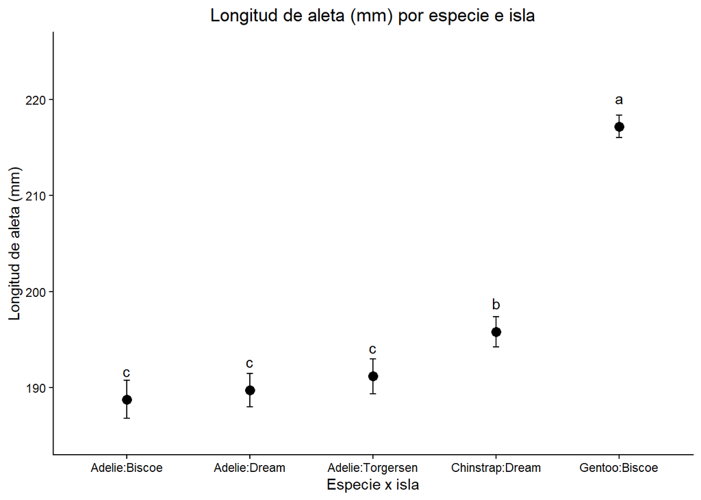

```r
ggplot(medias2vias, aes(row.names(medias2vias), flipper_length_mm)) +
  geom_errorbar(width = 0.05,
                aes(ymin = liIC95,
                    ymax = lsIC95)) +
  geom_point(shape = 19,
             size = 3) +
labs(title = "Longitud de aleta (mm) por especie e isla",
     y = "Longitud de aleta (mm)",
     x = "Especie x isla") +
  geom_text(aes(label = grupo),
            vjust = -2) +
  ylim(c(185,225)) +
  theme_classic() +
  theme(plot.title = element_text(hjust = 0.5))
```

Para que los valores de la especie Adelie aparezcan juntos en el gráfico podemos hacer lo siguiente:

Hacemos un resumen de las medias por especie por isla con la función `Summarize()` del paquete `FSA`:

```r
sum2vias <- Summarize(flipper_length_mm ~ species + island, data = penguins) # agregamos la segunda variable predictora (island) a nuestro resumen de datos
sum2vias
```

```
##     species    island   n     mean       sd min     Q1 median  Q3 max
## 1    Adelie    Biscoe  44 188.7955 6.729247 172 184.75  189.5 193 203
## 2    Gentoo    Biscoe 123 217.1870 6.484976 203 212.00  216.0 221 231
## 3    Adelie     Dream  56 189.7321 6.585083 178 185.00  190.0 193 208
## 4 Chinstrap     Dream  68 195.8235 7.131894 178 191.00  196.0 201 212
## 5    Adelie Torgersen  51 191.1961 6.232238 176 187.00  191.0 195 210
```

```r
sum2vias <- arrange(sum2vias, species) # con la función `arrange()` ordenamos las especies de la tabla resumen
sum2vias
```

```
##     species    island   n     mean       sd min     Q1 median  Q3 max
## 1    Adelie    Biscoe  44 188.7955 6.729247 172 184.75  189.5 193 203
## 2    Adelie     Dream  56 189.7321 6.585083 178 185.00  190.0 193 208
## 3    Adelie Torgersen  51 191.1961 6.232238 176 187.00  191.0 195 210
## 4 Chinstrap     Dream  68 195.8235 7.131894 178 191.00  196.0 201 212
## 5    Gentoo    Biscoe 123 217.1870 6.484976 203 212.00  216.0 221 231
```

Agregamos columnas con el error estándar (de la prueba de contraste) y los intervalos de confianza al 95%:

```r
sum2vias$SE <- medias2vias$se
sum2vias$IC95 <- sum2vias$SE * 1.96
sum2vias$liIC95 <- sum2vias$mean - sum2vias$IC95
sum2vias$lsIC95 <- sum2vias$mean + sum2vias$IC95
```

```r
sum2vias
```

```
##     species    island   n     mean       sd min     Q1 median  Q3 max        SE
## 1    Adelie    Biscoe  44 188.7955 6.729247 172 184.75  189.5 193 203 0.9994860
## 2    Adelie     Dream  56 189.7321 6.585083 178 185.00  190.0 193 208 0.8859497
## 3    Adelie Torgersen  51 191.1961 6.232238 176 187.00  191.0 195 210 0.9283633
## 4 Chinstrap     Dream  68 195.8235 7.131894 178 191.00  196.0 201 212 0.8039862
## 5    Gentoo    Biscoe 123 217.1870 6.484976 203 212.00  216.0 221 231 0.5977926
##       IC95   liIC95   lsIC95
## 1 1.958993 186.8365 190.7544
## 2 1.736461 187.9957 191.4686
## 3 1.819592 189.3765 193.0157
## 4 1.575813 194.2477 197.3993
## 5 1.171673 216.0153 218.3587
```

```r
sum2vias$grupo <- c("", "", "c", "b", "a")
```

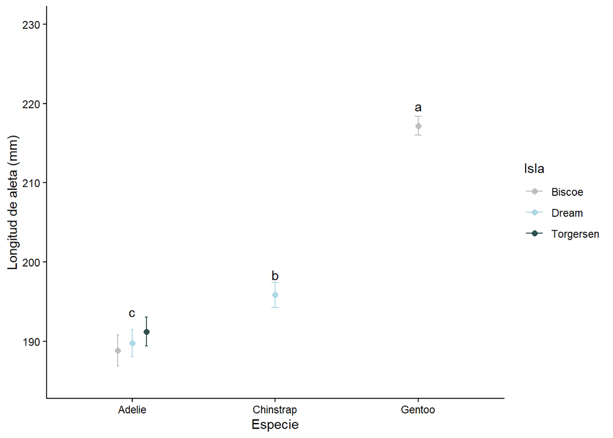

```r
# Gráfico de punto con barras de error
ggplot(sum2vias, aes(species, mean)) +
  geom_errorbar(aes(color = island, # indicamos que el color de las barras de error sea en base a la isla (segunda variable predictora)
                    ymin = liIC95,
                    ymax = lsIC95),
                width = 0.05,
                position = position_dodge(width = 0.3)) +
  geom_point(aes(color = island),
             shape = 19,
             size = 2,
             position = position_dodge(width = 0.3)) + # indicamos que el color de los puntos sea en base a la isla
labs(y = "Longitud de aleta (mm)",
     x = "Especie",
     color = "Isla") +
  scale_color_manual(values = c("gray", "lightblue", "darkslategray")) + # para especificar los colores de forma manual
  geom_text(aes(label = grupo),
            vjust = -1.5) +
  ylim(c(185,230)) +
  theme_classic()
```

```r
ggsave("Imagenes/anova2vias.jpg")
```

Volver arriba

Inicio